# Introduction

Prompt Engineering

Mick McQuaid

mcq@utexas.edu

University of Texas at Austin

06 Dec 2024

Welcome!

# Let me set the stage

- This is all new, this course, this topic
- There are no models for how it should be run
- We’re pioneering new ground

## That’s good and bad

- You can probably guess the good aspects of being a pioneer, but what about the bad?
- We may have to change course often.
- We may go down blind alleys.
- We *will* face a lot of uncertainty.
- If this kind of thing bothers you, you should drop the course and wait until we have done all the pioneering work and you can follow.
- $\langle$ Pause to let the room clear $\rangle$

## Constraint

- There are no prereqs. You may not even know how to spell AI
- $\langle$ Pause for laughter $\rangle$
- $\langle$ If no laughter, tell mother-in-law joke $\rangle$
- Since there are no prereqs, we have to start before the beginning.
- I need to tell you a little bit of history, so you get the context.

## Today’s plan

- We have to read Dhar (2024) for a bit of history.
- We’ll spend some time on that today, then we’ll a simple exercise.
- In fact, the general format of the class will usually be some lecture followed by some exercises.

# But first, TANSTAAFL

That stands for “There ain’t no such thing as a free lunch”

Many people think AI will provide a free lunch. I don’t.

[figure not shown]

You will have to work (think) to make AI work (think) for you

$\langle$ Pause to let the room clear $\rangle$

# Paradigm shifts in AI

Dhar (2024) covers four periods in AI history and the paradigm shifts between them.

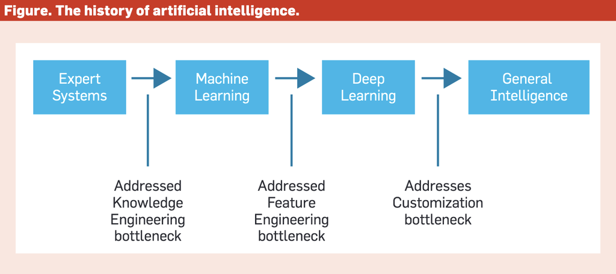

This isn’t all of AI history but is a simplified picture that will help us understand the task we face in making AI work for us.

## Expert Systems

- Work in well-circumscribed domains where expertise is identifiable and definable
- Perform well at specific tasks where expertise can be extracted from humans
- Represent problems as relationships between situations and outcomes
- Considered intelligent if performing like human experts
- Example: *high pallor* $\Rightarrow$ *excess bilirubin*

## Machine Learning

- Learn models from curated examples
- Driven by database technology, Internet, abundance of data
- Grew in parallel with neural networks
- Rely on loss functions measuring difference between predictions and empirical reality
- Influenced by philosopher Karl Popper
- Example: Predicting pneumonia from historical medical records of people with and without pneumonia

## Deep Learning

- Usually conducted via deep neural networks
- Takes raw input (images, language, sound) instead of human description
- Acts as a *universal function approximator*
- Learns features implicitly associated with raw input
- Example: Vision system sees lines, colors, curves and, through successive layers of neurons, combines them into doors, windows, street signs

## General Intelligence

- Pre-trained models integrate a large corpus of general and specialized models *not* optimized for a single task
- Language is a critical carrier of knowledge, powering large language models (LLMs)
- Pre-trained models learn through self-supervision on uncurated data, e.g., WWW

## Paradigm Shifts

- Draws on the work of philosopher Thomas Kuhn
- Perceives history of science as punctuated by upheavals displacing dominant paradigms
- Identifies bottlenecks that lead to paradigm shifts

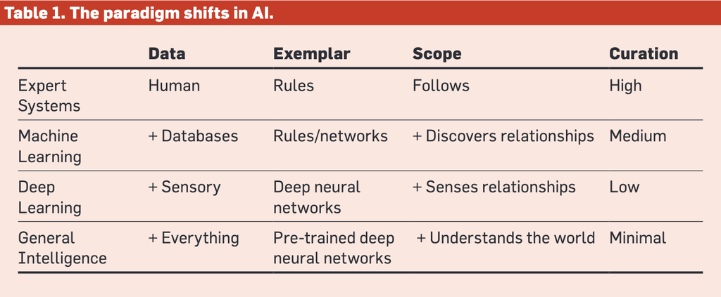

# Current Paradigm in Science

AI as general-purpose technology

General-purpose technology, such as electricity or the Internet, is defined by economists as a new method for producing and inventing that is important enough to have a protracted aggregate economic impact across the economy

## Characteristics of General-Purpose Technologies

- pervasiveness
- inherent potential for technical improvements
- innovational complementarities

## Challenging characteristics of the current paradigm

- opacity to humans, i.e., AI can’t explain itself well (yet)
- explanation and transparency are important to humans
- legal questions of ownership and control of uncurated data, weights, and outputs
- nature of uncurated data as biased, rife with falsehood and noise
- AI is not designed to be truthful and is noisy and inconsistent

## State of the world is a factor

- Alignment problem: are our subgoals aligned with our goals?
- and are the goals and subgoals aligned with those of AI?
- Example: Goal *Save the planet* might cause the AI to infer subgoal *eliminate humans*
- Scalability simplifies the work of bad actors

## Human nature

- deepfake porn of hundreds of thousands of ordinary women was overlooked, but policy action was taken when a celebrity was the victim
- policy action is generally slow compared to technological advances
- policy action tends to favor the very rich and well-connected
- this has implications for all the legal and policy questions of AI

END

# References

Dhar, Vasant. 2024. “The Paradigm Shifts in Artificial Intelligence.” *Commun. ACM* 67 (11): 50–59. https://doi.org/10.1145/3664804.

# Colophon

This slideshow was produced using `quarto`

Fonts are *Robot Light*, *Roboto Bold*, and *JetBrains Mono Nerd Font*

[figure not shown]